# Peer Assignment 1

This is an R Markdown document for Peer Assignment 1. This assignment uses data from personal activity monitoring devices like Fitbit. The assignment uses data collected at 5-minute intervals through out the day. The data consists of two months of data collected during the months of October and November, 2012 and include the number of steps taken in 5 minute intervals each day.

First we will download and prepare the data in order to analyze the data and answer questions.

```r
library(plyr)
library(reshape2)
library(RCurl)
library(Hmisc)
library(dplyr)
library(data.table)
library(lubridate)
library(ggplot2)
library(scales)
```

```r
temp <- tempfile()
download.file("https://d396qusza40orc.cloudfront.net/repdata%2Fdata%2Factivity.zip", temp, method = "libcurl")
activitydataset <- read.csv(unz(temp, "activity.csv"), header = TRUE, sep = ",")
unlink(temp)
```

**Question 1 - What is the mean total number of steps taken per day?**  
**1.1** The first step is to calculate the total number of steps taken per day.

```r
countdaily <- activitydataset[!is.na(activitydataset$steps),]
totalstepsperday <- aggregate(countdaily$steps, list(Day = countdaily$date), sum)
colnames(totalstepsperday)[2] <- "TotalSteps"
totalstepsperday$Day <- as.Date(totalstepsperday$Day)
```

**1.2** Make a histogram of the total number of steps taken each day.

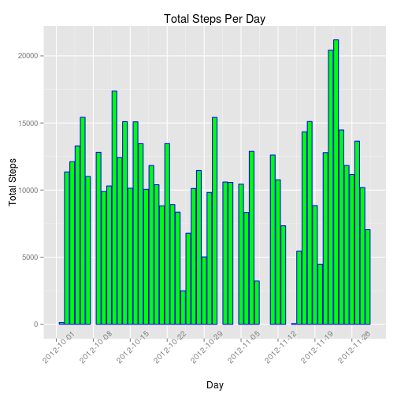

**1.3** Calculate and report the mean and median of the total number of steps taken per day.

```r
meanmedian <- with(countdaily, aggregate(countdaily$steps, list(Day = countdaily$date), function(x)
  {c(Mean=mean(x) ,Median=median(x, na.rm=TRUE) )}))
names(meanmedian) <- c("Day","Steps")
summarymean <- mean(countdaily$steps)
summarymedian <- median(countdaily$steps)
```

[output not shown]

[output not shown]

**Question 2 - What is the average daily activity pattern?**

**2.1** Create a data frame and variables containing the data needed to create the requested graph and answer the follow-on question.

```r
meanstepsperintday <- aggregate(countdaily$steps, list(Interval = countdaily$interval), mean)
colnames(meanstepsperintday)[2] <- "MeanIntervalSteps"
maxsteps <- max(meanstepsperintday$MeanIntervalSteps)
intwithmaxsteps <- meanstepsperintday[meanstepsperintday$MeanIntervalSteps == maxsteps,]
```

**2.2** Next, make a time series plot of the 5-minute interval (x-axis) and the average number of steps taken, which is averaged across all days (y-axis). Also Show which 5-minute interval, on average across all the days in the dataset, contains the maximum number of steps.

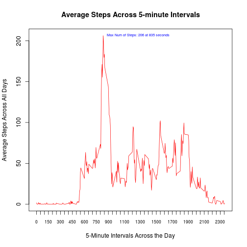

**Question 3 - Imputing missing values**

**3.1** Calculate and report the total number of missing values in the dataset (i.e. the total number of rows with NAs).

```r
numofNAs <- apply(activitydataset, 2, function(x) length(which(is.na(x))))
numofNAs <- numofNAs[1]
```

```
## The the total numbmer of missig values: 2304
```

**3.2** Devise a strategy for filling in all of the missing values in the dataset.

The strategy is to replace NAs in “steps” column with mean for total steps for the entire dataset since NAs are assigned to an entire day and not just intermitently throughout a day.

```r
NoNAsdataset <- merge(meanstepsperday, activitydataset, by.x="Day", by.y="date", all=TRUE)
NoNAsdataset[, 2][is.na(NoNAsdataset[, 2])] <- summary_numbers[4]
NoNAsdataset[, 3][is.na(NoNAsdataset[, 3])] <- summary_numbers[4]
```

**3.3** Create a new dataset that is equal to the original dataset but with the missing data replaced.

```r
Totalmeanmedian <- with(NoNAsdataset, aggregate(NoNAsdataset$steps, list(Day = NoNAsdataset$Day),
  function(x) {c(Total=sum(x), Mean=mean(x), Median=median(x, na.rm=TRUE)) }))
Totalmeanmedian <- cbind(Totalmeanmedian, Totalmeanmedian$x[,1], Totalmeanmedian$x[,2],Totalmeanmedian$x[,3])
Totalmeanmedian <- Totalmeanmedian [ , - 2 ]
names(Totalmeanmedian) <- c("Day","TotalSteps","MeanSteps","MedianSteps")
Totalmeanmedian$Day <- as.Date(Totalmeanmedian$Day)
```

**3.4** Make a histogram of the total number of steps taken each day.

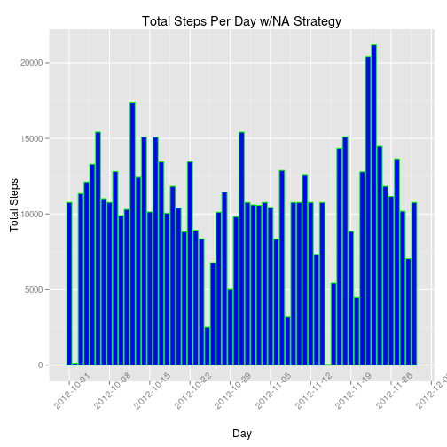

**3.5** Calculate and report the mean and median of the total number of steps taken per day.

```r
meanmedian2 <- with(NoNAsdataset, aggregate(NoNAsdataset$steps, list(Day =NoNAsdataset$Day),
  function(x) {c(Mean=mean(x) ,Median=median(x, na.rm=TRUE) )}))
names(meanmedian2) <- c("Day","Steps")
summarymean2 <- mean(NoNAsdataset$steps)
summarymedian2 <- median(NoNAsdataset$steps)
```

[output not shown]

[output not shown]

These mean/median values don't differ from the estimates from the first part of the assignment because the strategy used only resulted in the newly calculated mean being different at the 10,000th decimal place. The strategy had negligible or no impact on the newly calculated mean and median.

**Question 4 - Are there differences in activity patterns between weekdays and weekends?**

**4.1** Create a new factor variable in the dataset with two levels – “weekday” and “weekend” indicating whether a given date is a weekday or weekend day.

```r
NoNAsdataset$DayName <- weekdays(as.Date(NoNAsdataset$Day))
for (count in 1:nrow(NoNAsdataset)) {
ifelse(NoNAsdataset$DayName == "Saturday" || NoNAsdataset$DayName == "Sunday",
                         NoNAsdataset$DayType <- "Weekend", NoNAsdataset$DayType <- "Weekday")}
NoNAsdataset$DayType <- factor(c("Weekday", "Weekend"))

meanstepsperintday2 <- aggregate(NoNAsdataset$steps, list(Interval = NoNAsdataset$interval,
  NoNAsdataset$DayType), mean)
colnames(meanstepsperintday2)[2] <- "DayType"
colnames(meanstepsperintday2)[3] <- "MeanIntervalSteps"
meanstepsperintday2$DayType <- factor(c("Weekend", "Weekday"))
maxsteps2 <- max(meanstepsperintday2$MeanIntervalSteps)
intwithmaxsteps2 <- meanstepsperintday2[meanstepsperintday2$MeanIntervalSteps == maxsteps2,]
```

**4.2** Make a panel plot containing a time series plot of the 5-minute interval (x-axis) and the average number of steps taken across all weekday days or weekend days (y-axis).

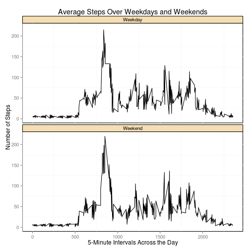